# Bayesian GLM Part3

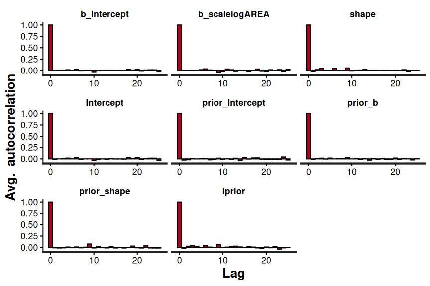

```r
peake_brm4$fit |> stan_ac()
```

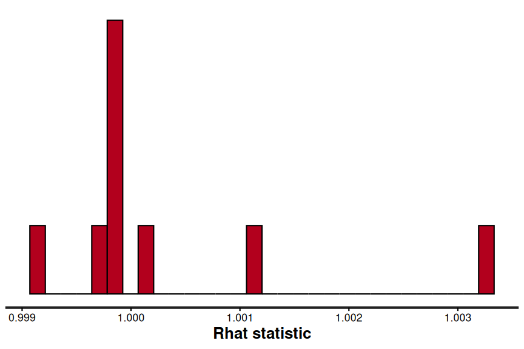

```r
peake_brm4$fit |> stan_rhat()
```

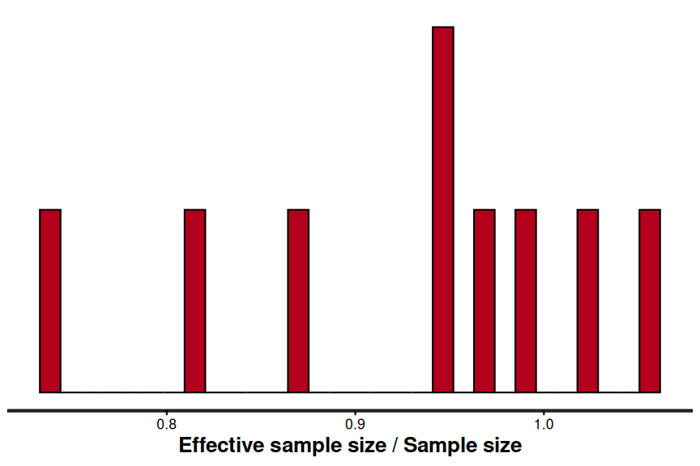

```r
peake_brm4$fit |> stan_ess()
```

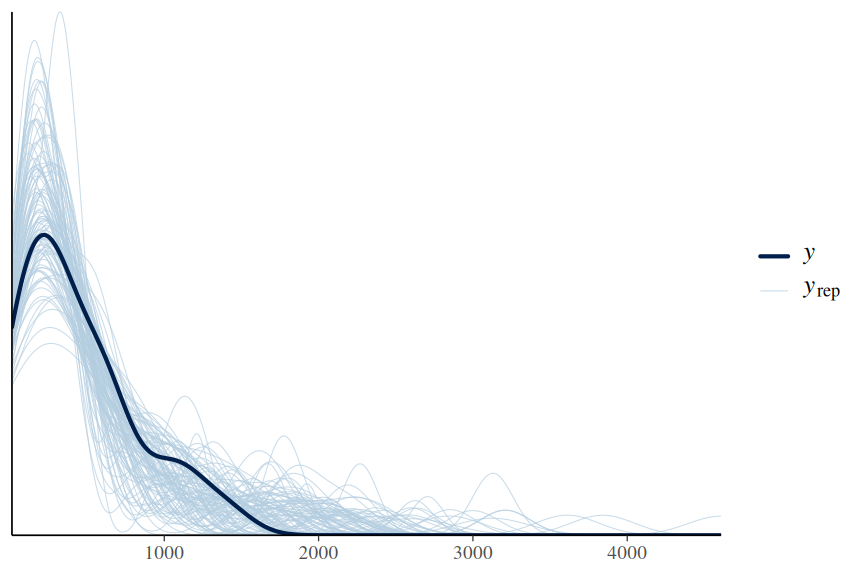

```r
pp_check(peake_brm4, x='AREA',type='dens_overlay', ndraws = 100)
```

```
Using all posterior draws for ppc type 'intervals' by default.
```

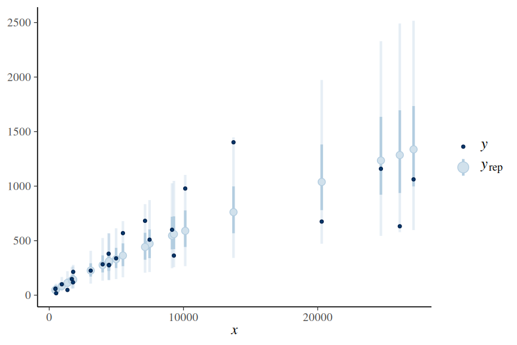

```r
pp_check(peake_brm4, x='AREA', type='intervals')
```

**DHARMa residuals**

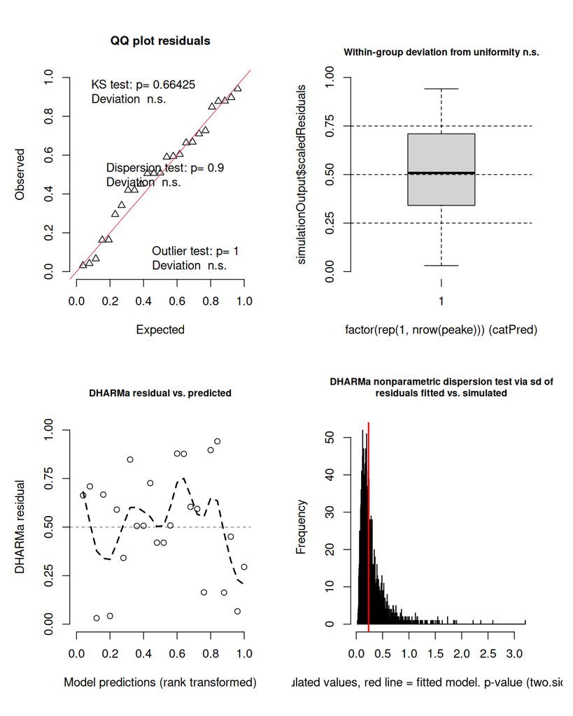

```r
peake_resids <- make_brms_dharma_res(peake_brm4, integerResponse = FALSE)
wrap_elements(~testUniformity(peake_resids)) +
               wrap_elements(~plotResiduals(peake_resids, form = factor(rep(1, nrow(peake))))) +
               wrap_elements(~plotResiduals(peake_resids, quantreg = FALSE)) +
               wrap_elements(~testDispersion(peake_resids))
```

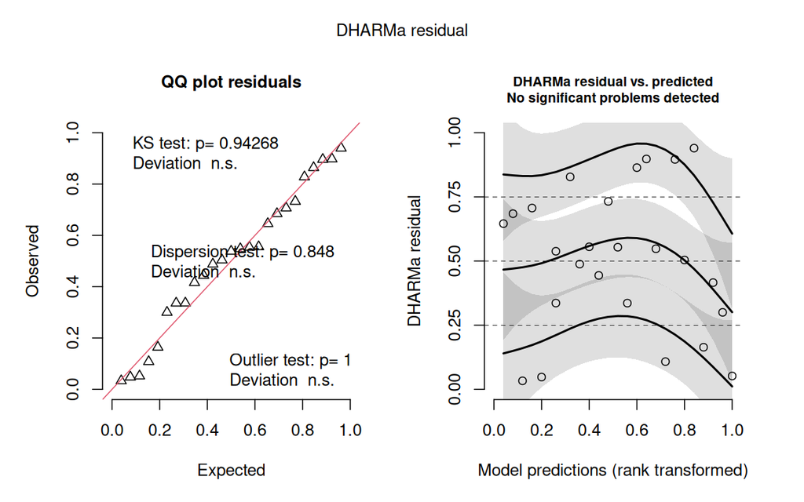

```r
preds <- posterior_predict(peake_brm4,  ndraws=250,  summary=FALSE)
peake_resids <- createDHARMa(simulatedResponse = t(preds),
                            observedResponse = peake$INDIV,
                            fittedPredictedResponse = apply(preds, 2, median),
                            integerResponse = TRUE)
plot(peake_resids)
```

**LOOIC**

Different models can be compared via information criterion. LOO (Leave One Out) IC is similar to AIC except that AIC does not consider priors and assumes that the posterior likelihood is multivariate normal. LOO AIC does not and integrates over all uncertainty.

- ELPD: is the theoretical expected log pointwise predictive density for a new dataset and can be estimated via leave-one-out cross-validation.
- `elpd_loo`: is the Bayesian LOO estimate of ELPD
- `SE` of `elpd_loo`: is the Monte Carlo standard error is the estimate for the computational accuracy of MCMC and importance sampling used to compute `elpd_loo`
- `p_loo`: is the difference between `elpd_loo` and the estimated from non-cross validated ELPD and therefore is a measure of the relative extra difficulty of predicting new data compared to the observed data. It can also be a meaure of the effective number of parameters:
  - in a well behaved model, `p_loo` will be less than the number of estimated parameters and the total sample size.
  - in a misspecified model, `p_loo` will be greater than the number of estimated parameters and the total sample size.
- `Pareto k`: is a relative measure of the influence of each observation as well as the accuracy with which the associated leave one out calculations can be estimated.
  - when `k < 0.5`: the corresponding components can be accurately estimated
  - when `0.5 < k < 0.7`: the accuracy is lower but still acceptable
  - when `k>0.7`: the accuracy is too low and `elpd_loo` is unreliable. This can also suggest a misspecified model.

More information about the above can be gleaned from [https://mc-stan.org/loo/reference/loo-glossary.html].

Start with the Poisson model

```r
(peake_brm2.loo <- loo(peake_brm2))
```

```
Computed from 2400 by 25 log-likelihood matrix.

         Estimate    SE
elpd_loo   -929.0 297.7
p_loo       117.1  46.3
looic      1858.1 595.4
------
MCSE of elpd_loo is NA.
MCSE and ESS estimates assume independent draws (r_eff=1).

Pareto k diagnostic values:
                         Count Pct.    Min. ESS
(-Inf, 0.7]   (good)     18    72.0%   69
   (0.7, 1]   (bad)       3    12.0%   <NA>
   (1, Inf)   (very bad)  4    16.0%   <NA>
See help('pareto-k-diagnostic') for details.
```

**Conclusions:**

- `p_loo` is substantially higher than the number of estimated parameters
- there are some `Pareto k` values identified as bad or even very bad

Now for the Negative Binomial model

```r
(peake_brm4.loo <- loo(peake_brm4))
```

```
Computed from 2400 by 25 log-likelihood matrix.

         Estimate   SE
elpd_loo   -156.3  5.8
p_loo         2.9  0.8
looic       312.6 11.6
------
MCSE of elpd_loo is 0.1.
MCSE and ESS estimates assume MCMC draws (r_eff in [0.8, 1.0]).

All Pareto k estimates are good (k < 0.7).
See help('pareto-k-diagnostic') for details.
```

**Conclusions:**

- `p_loo` is lower than the number of estimated parameters
- there are no bad `Pareto k` values

We can also compare the models.

The difference in Expected Log Pointwise Probability Density (`elpd_dff`) computes the difference in `elpd_loo` of two models (expressed relative to the higher model). The difference in `elpd_diff` will be negative if the expected out-of-sample predictive accuracy of the first model is higher. If the difference is be positive then the second model is preferred.

Note, the above assumes that both models are valid. In the current case, we know that the Poisson model was overdispersed and thus it should not be a genuine candidate. Nevertheless, we will compare the Poisson to the Negative Binomial for illustrative purposes.

```r
loo_compare(peake_brm2.loo, peake_brm4.loo)
```

```
      model elpd_diff se_diff p_worse diag_diff      diag_elpd
 peake_brm4       0.0     0.0      NA
 peake_brm2    -772.7   293.4    1.00   N < 100 7 k_psis > 0.7
```

```
Diagnostic flags present.
See ?`loo-glossary` (sections `diag_diff` and `diag_elpd`)
or https://mc-stan.org/loo/reference/loo-glossary.html.
```

**Conclusions:**

- the `elpd_diff` is negative, indicating that the first model (Negative Binomial) is better.

# 9 Partial effects plots

**rstanarm**

**ggpredict**

```
Data points may overlap. Use the `jitter` argument to add some amount of
  random variation to the location of data points and avoid overplotting.
```

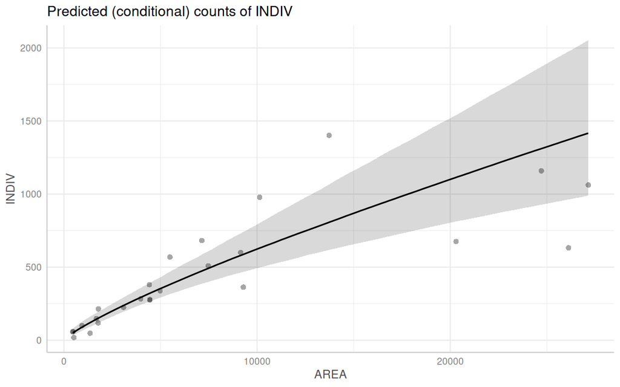

```r
peake_rstanarm4 |> ggpredict() |> plot(show_data=TRUE)
```

**ggemmeans**

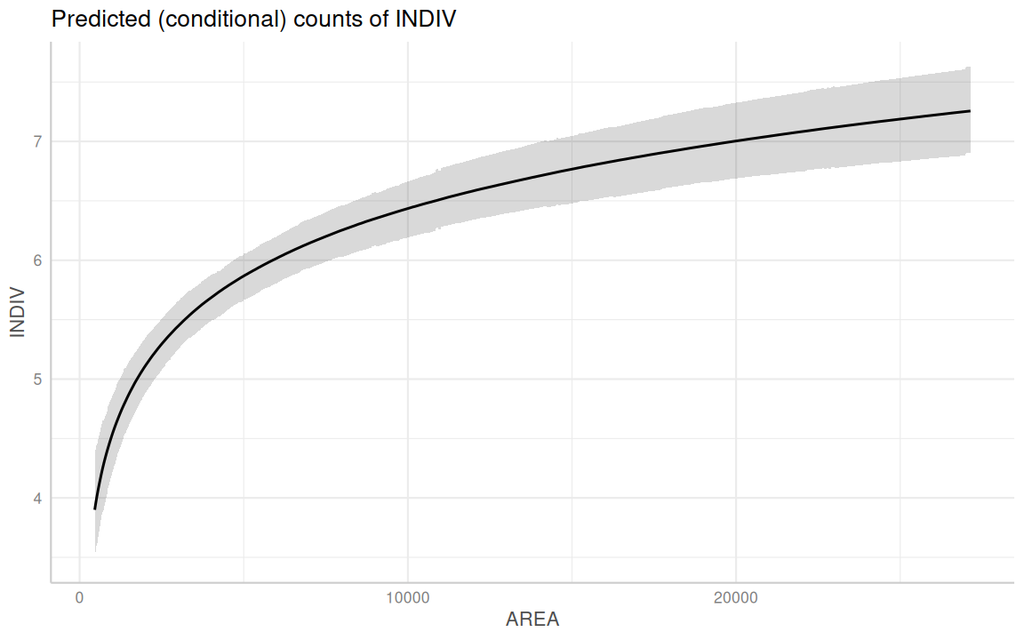

```r
## Note, does not seem to backtransform...
peake_rstanarm4 |> ggemmeans(~AREA, type = "fixed", back.transform = TRUE) |> plot()
```

**epred_draws**

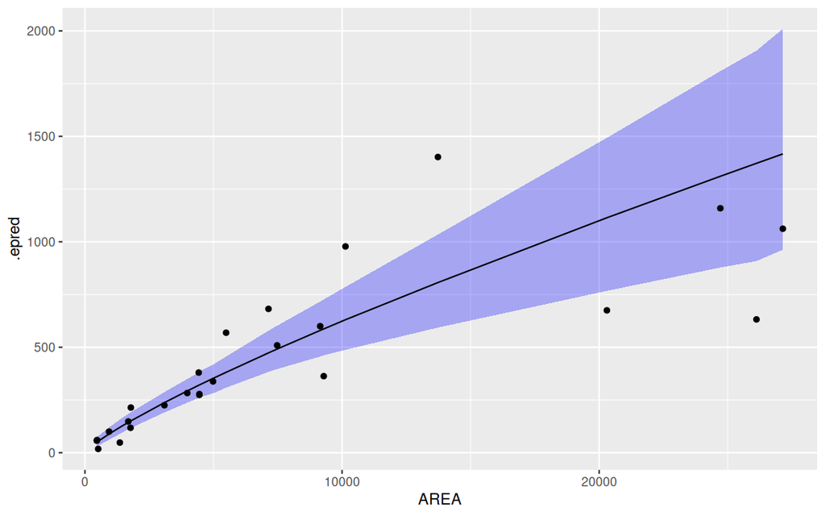

```r
peake_rstanarm4 |> epred_draws(newdata=peake) |>
  median_hdci() |>
  ggplot(aes(x=AREA, y=.epred)) +
  geom_ribbon(aes(ymin=.lower, ymax=.upper), fill='blue', alpha=0.3) +
  geom_line() +
  geom_point(data=peake,  aes(y=INDIV,  x=AREA))
```

**brms**

**conditional_effects**

```
Ignoring unknown labels:
• fill : "NA"
• colour : "NA"
Ignoring unknown labels:
• fill : "NA"
• colour : "NA"
```

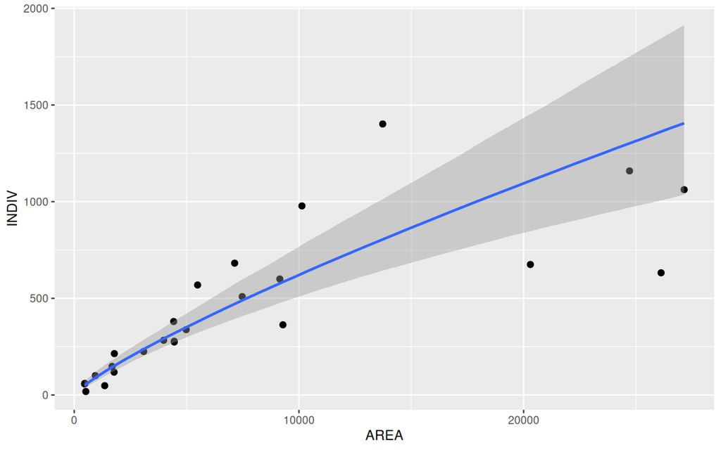

```r
peake_brm4 |> conditional_effects() |> plot(points = TRUE)
```

```
Ignoring unknown labels:
• colour : "NA"
Ignoring unknown labels:
• colour : "NA"
```

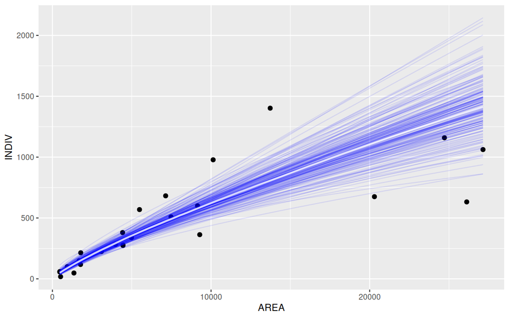

```r
peake_brm4 |> conditional_effects(spaghetti=TRUE,ndraws=200) |> plot(points = TRUE) + theme_classic()
```

```
Ignoring unknown labels:
• colour : "NA"
Ignoring unknown labels:
• colour : "NA"
```

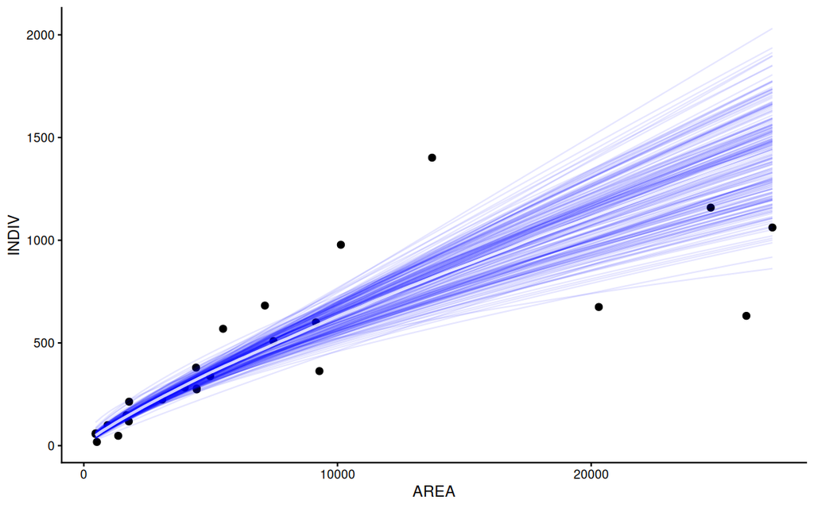

```r
ce <- peake_brm4 |> conditional_effects(spaghetti=TRUE,ndraws=200)
plot(ce, points = TRUE, plot = FALSE)[[1]] + theme_classic()
```

**ggpredict**

```
Data points may overlap. Use the `jitter` argument to add some amount of
  random variation to the location of data points and avoid overplotting.
```

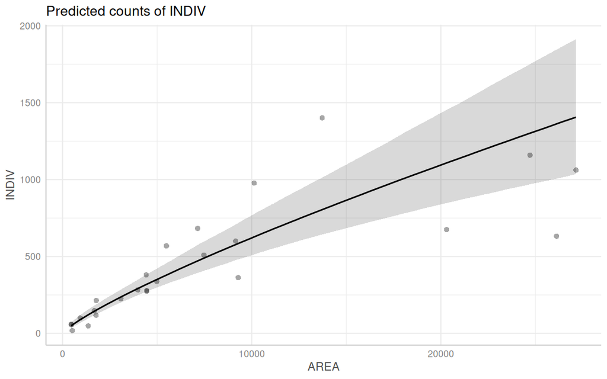

```r
peake_brm4 |> ggpredict() |> plot(show_data=TRUE)
```

**ggemmeans**

```
Data points may overlap. Use the `jitter` argument to add some amount of
  random variation to the location of data points and avoid overplotting.
```

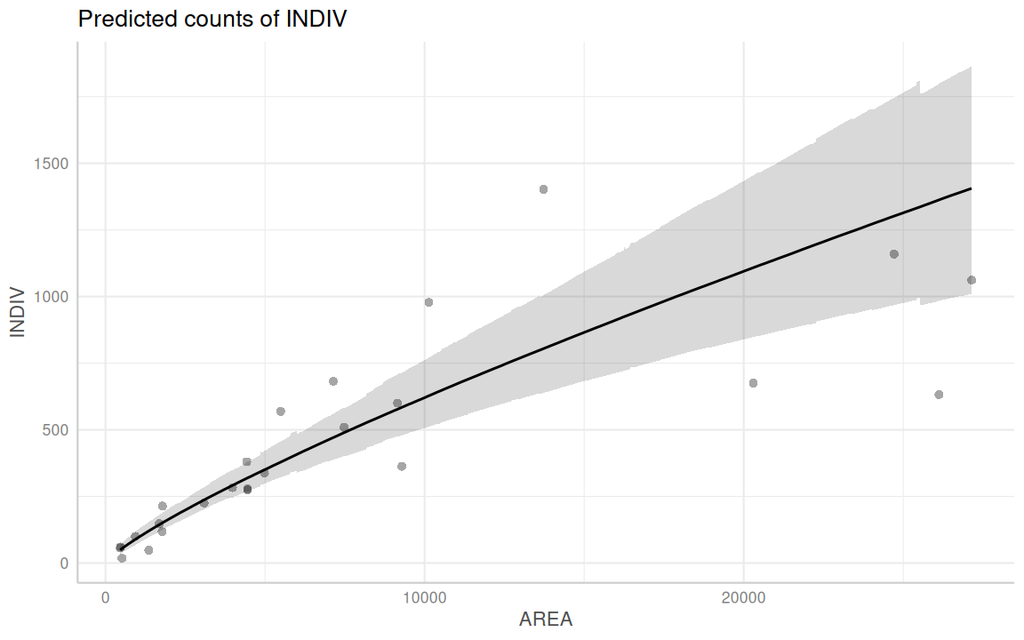

```r
peake_brm4 |> ggemmeans(~AREA) |> plot(show_data=TRUE)
```

**epred_draws**

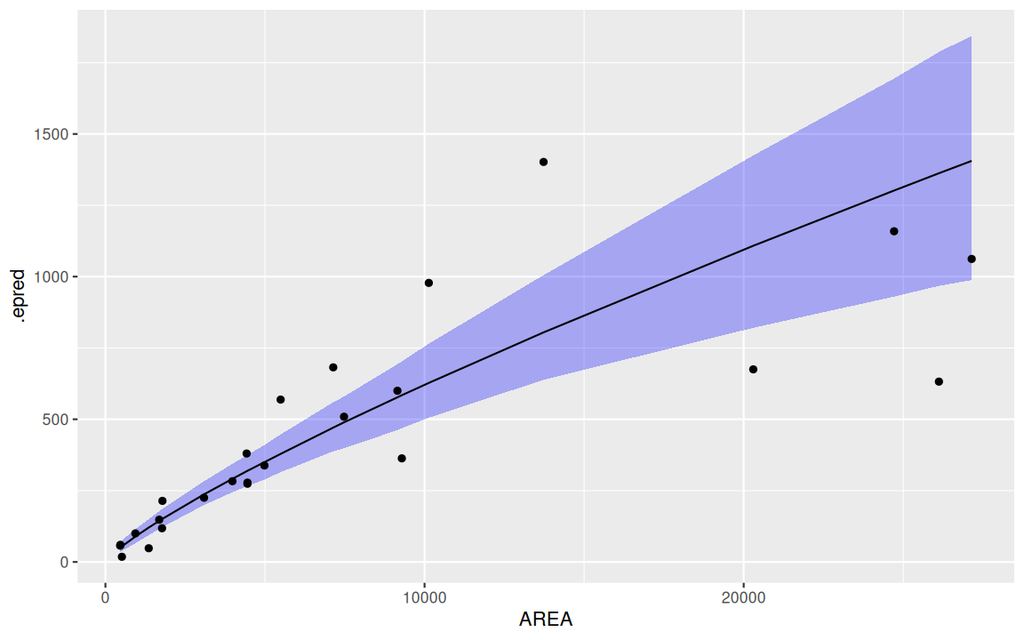

```r
peake_brm4 |> epred_draws(newdata=peake) |>
  median_hdci() |>
  ggplot(aes(x=AREA, y=.epred)) +
  geom_ribbon(aes(ymin=.lower, ymax=.upper), fill='blue', alpha=0.3) +
  geom_line() +
  geom_point(data=peake,  aes(y=INDIV,  x=AREA))
```